# EDA base RED Wine por Ericsson Graciolli

# Seção de Gráficos Univariados

O conjunto de dados wineQualityReds.csv possui 1599 observações e 13 variaveis relacionadas. No histograma abaixo distribuiremos as obserções de acordo do os valores atribuídos à variável quality.

### Histograma da variável qualidade segmentada por avaliação

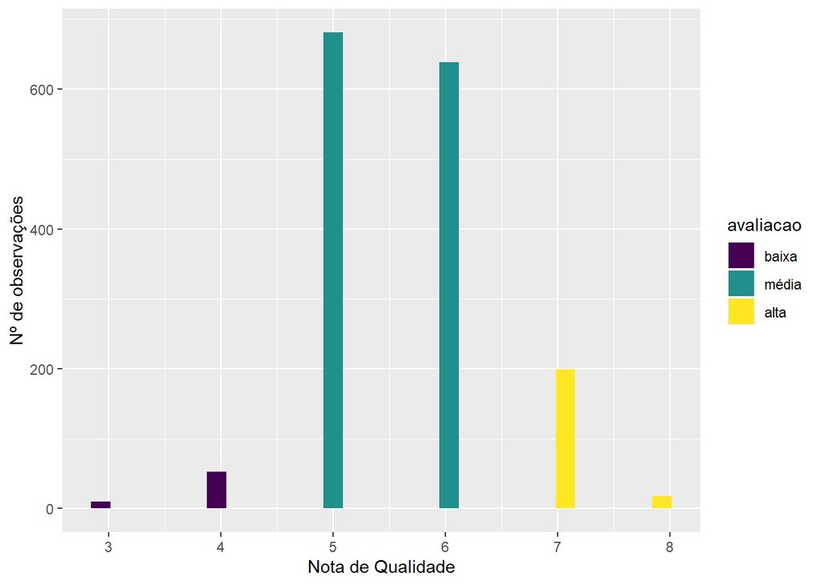

### Distribuição das demais variáveis numéricas em um gráfico consolidado

Para entender o comportamento dos dados no conjunto analisaremos a distribuição das demais variáveis numéricas em um gráfico consolidado.

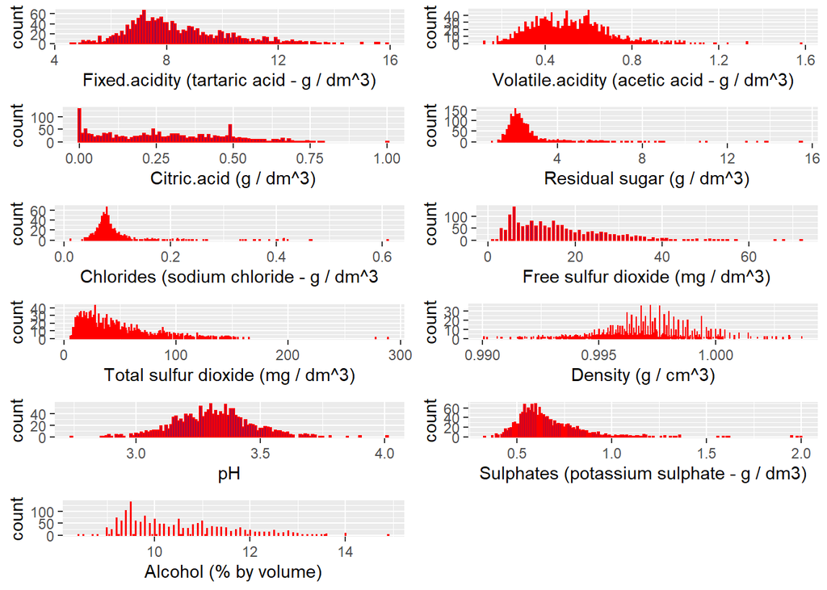

# Análise Univariada

### Qual é a estrutura do conjunto de dados?

O conjunto de dados possui 1599 observações e 13 variavéis, originalmente. Adicionalmente foi criada uma nova variavel para representar a variavel qualidade de forma categórica. E a maioria das observações enquada-se no valor de qualidade igual a 5, ou 6.

### Quais são os principais atributos de interesse deste conjunto de dados?

O atributo alvo com que estaremos trabalhando inicialmente é a variavel qualidade. E através do processo de EDA buscaremos identificar que outros atributos influenciam a qualidade.

### Quais outros atributos você acha que podem lhe auxiliar na investigação destes atributos de interesse?

Eu imagino que os atributos: alcohol, residual.sugar e fixed.acidity possam ser um ponto de partida interessante para a análise.

### Você criou novas variáveis a partir dos atributos existentes no conjunto de dados?

Sim, foi criada a variavel avaliacao para representar a variavel qualidade de forma categorica, facitando a visualizacao de algumas informações nos graficos plotados mais adiante.

### Dos atributos investigados, distribuições incomuns foram encontradas? Você aplicou operações nos dados para limpá-los, ajustá-los ou mudar a forma dos dados? Se sim, por quê?

# Seção de Gráficos Bivariados

### Matriz de correlação entre as variáveis do conjunto de dados

Por meio da matriz de correlação podemos encontrar os relacionamentos mais significativos entre as variáveis do conjunto de dados.

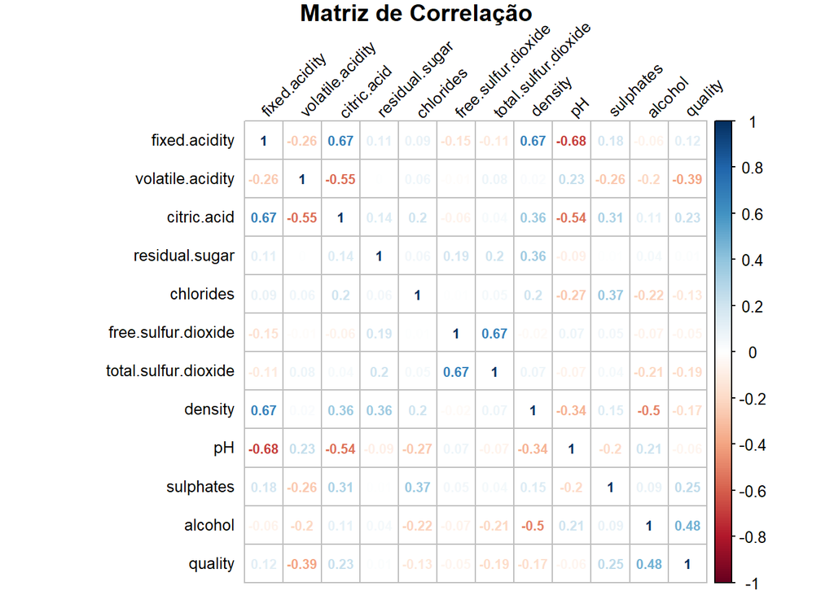

### Box plot entre Teor Alcoólico e Qualidade

Como existe uma correlação significativa entre as variáveis alcohol e quality podemos analisar adistribuição das observações entre as categorias de Avaliação. E verificamos que existe uma diferenciação do teor alcoólico dos vinhos com uma avaliação mais alta.

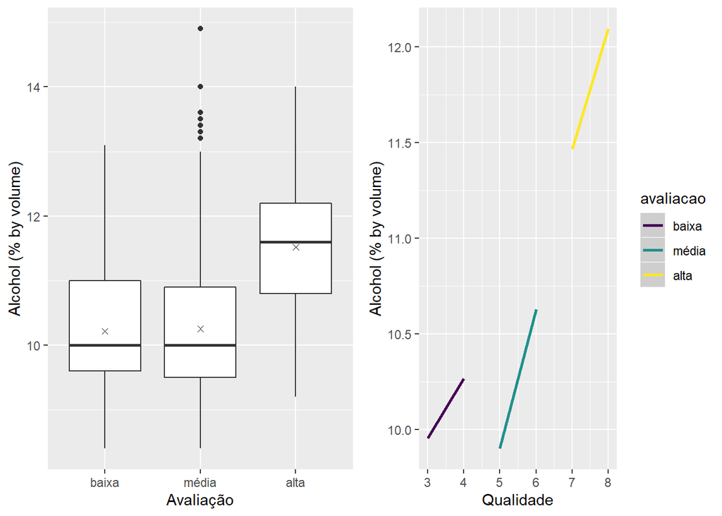

### Box plot entre Volatile.acidity e Quality

Também existe uma correlação significativa entre as variáveis volatie.acidity e quality podemos analisar adistribuição das observações entre as categorias de Avaliação. Nesse caso, observamos que a volatile.acidity cai de acordo com que as notas de qualidade aumentam.

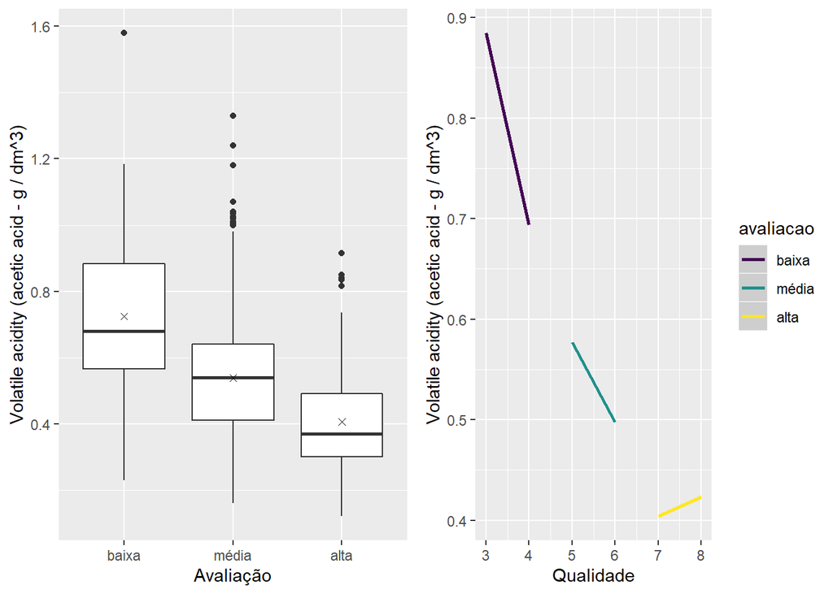

### Box plot entre Sulphates e Quality

Além das correlações apresentadas anteriormente, há uma correlação significativa entre as variáveis sulphates e quality. Assim, podemos analisar adistribuição das observações entre as categorias de Avaliação. E podemos observar que a variável sulphates muda de acordo com as notas de qualidade aummentam.

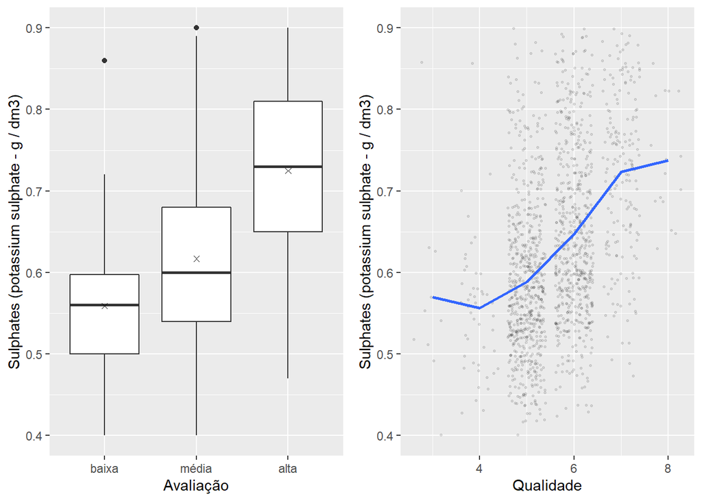

### Relação entre Qualidade e as três variáveis com maior correlação

Após analisarmos cada uma das uma das correlações de forma individualizada, podemos construir uma visão consolidada entre elas. E verificamos o comportamento de cada uma delas com o aumento das notas de qualidade, onde alcohol tem uma variação positiva, volatile.acidity negativa e sulphates segue uma distribuição normal.

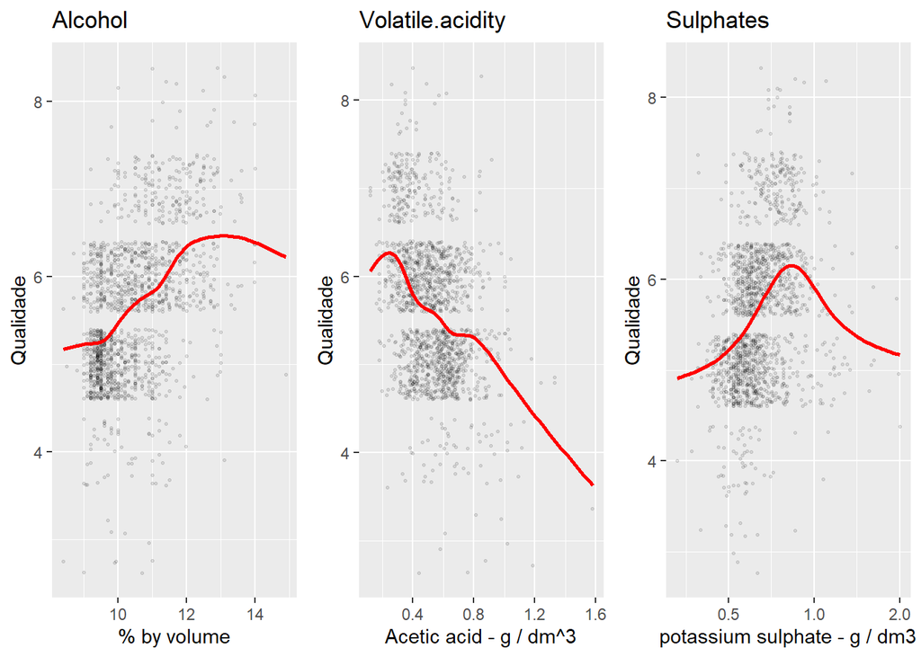

### Correlação entre Fixed.acidity e Density

Uma das correlações que me chamaram a atenção na matriz de correlação, foi a que existe entre as variáveis fixed.acidity e density (correlação de 0.668). Dessa forma considerei importante avaliá-la. E apesar de ser possível verificar constatar um comportamento dependente, devido a correlação com quality ser baixa, uma investigação mais aprofundada é descartada.

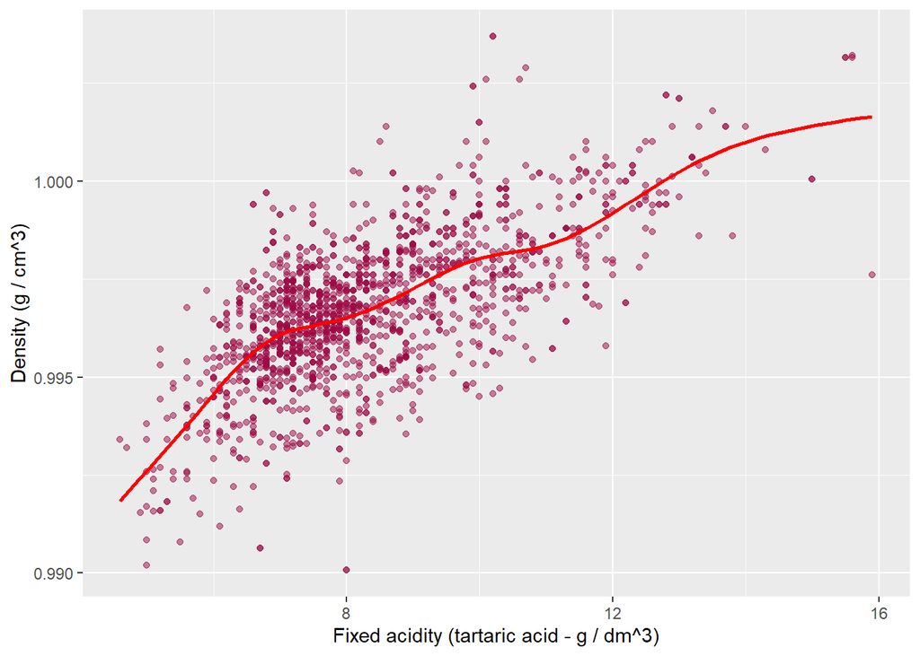

# Análise Bivariada

### Discuta sobre alguns dos relacionamentos observados nesta parte da investigação. Como os atributos de interesse variaram no conjunto de dados?

Ao analisar a matriz de correlação observei que as três maiores correlações estão entre a variavel qualidade são com: alcohol, volatile.acidity e sulphates. Sendo que a correlação mais forte é com alcohol (0.476) e tem uma tendência positiva. Já com relação a variável volatile.acidity (-0.391) a tendência é negativa. E com a variável sulphates (0.251) a corelação é menor e positiva. No caso do gráfico entre sulphates e quality optei em representar a variável sulphates na escala logaritmica (log10), fazendo com que a distribuição aproximasse-se de um padrão normal.

### Você observou algum relacionamento interessante entre os outros atributos (os que não são de interesse)?

Existem outras correlações interessantes no conjunto de dados:

- Alcohol e Density (-0.496),
- Volatile.acidity e Citric.acid (-0.552) e
- fixed.acidity e density (0.668)

Obs.: A relação entre free.sulfur.dioxide e total.sulfur.dioxide tem o mesmo valor de correlação (0.668) do par fixed.acidity e density, mas por elas já serem relacionadas por natureza optei por não considerá-las como um relacionamento interessante.

### Qual foi o relacionamento mais forte encontrado?

O relacionamento mais forte encontrado foi entre as variaveis:

- fixed.acidity e pH (-0.683).

# Seção de Gráficos Multivariados

### O relacionamento entre Alcohol, Volatile.acidity e Quality

Como os maiores índices de correlação da variável quality são com as variáveis alcohol e volatile.acidity, iremos representá-las em um gráfico segmentado pelo grau de avaliação.

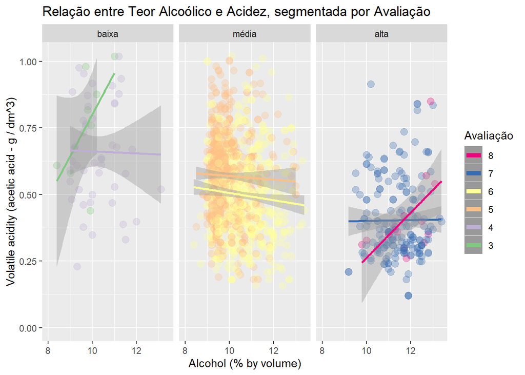

### Investigação sobre transformações na variável Alcohol

Ao investigar se a varável Alcohol assumiria uma distribuição similar a distribuição normal, testei se as transformações com log10 e raiz cúbica influenciariam no resultado final e conclui que não.

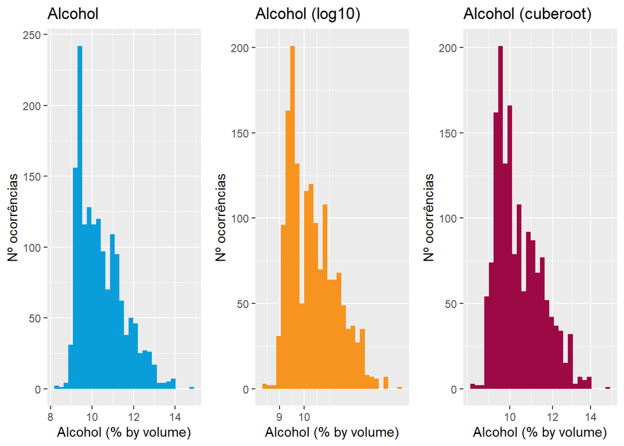

### Correlação entre alcohol, density e quality

Uma outra investigação possível é analisar o comportamento das variáveis alcohol e density, segmentando-a pelo grau de avaliação. Mas apesar da suspeita possuir fundamento não foi evidenciado nenhum comportamento distinto no conjunto de dados.

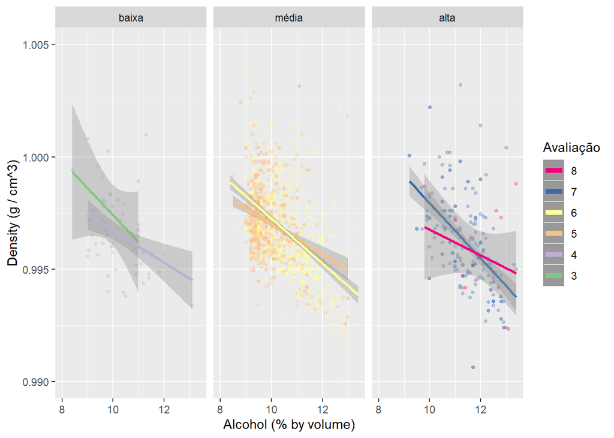

### Correlação entre Volatile.acidity, Citric.acid e Quality

Mais uma investigação realizada foi da relação entre volatile.acidity e citric.acid, com a identificação do grau de avaliação no mesmo gráfico. Nesse caso também não foi evidenciado nenhum comportamento distinto no conjunto de dados.

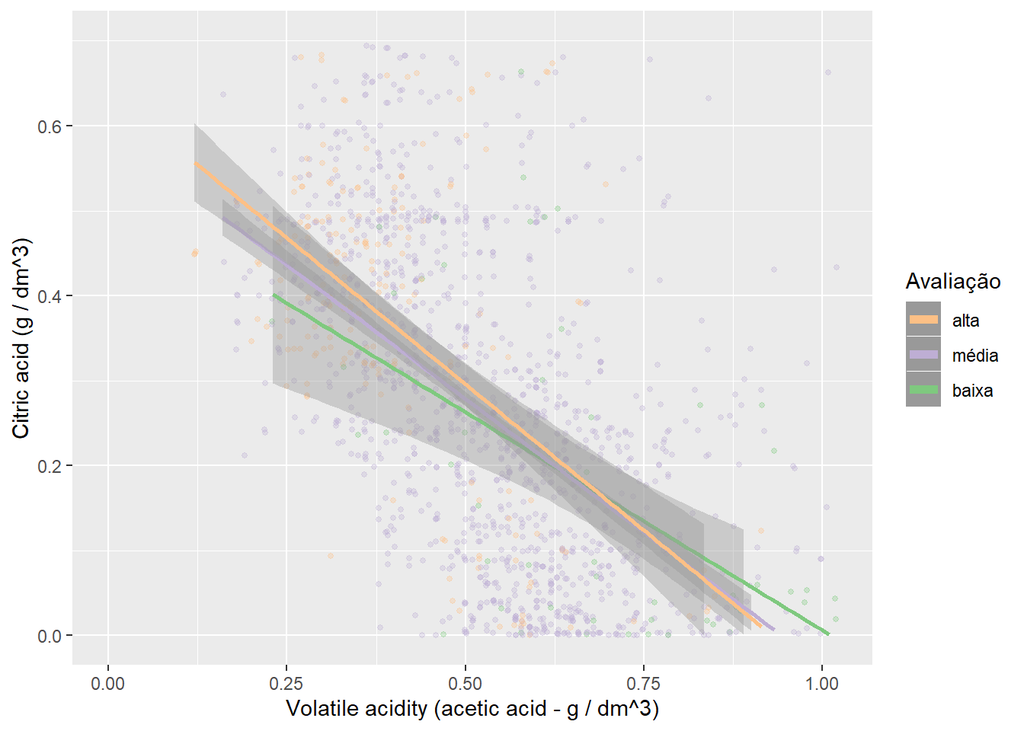

### Correlação entre Fixed.acidity, pH e Qualidade

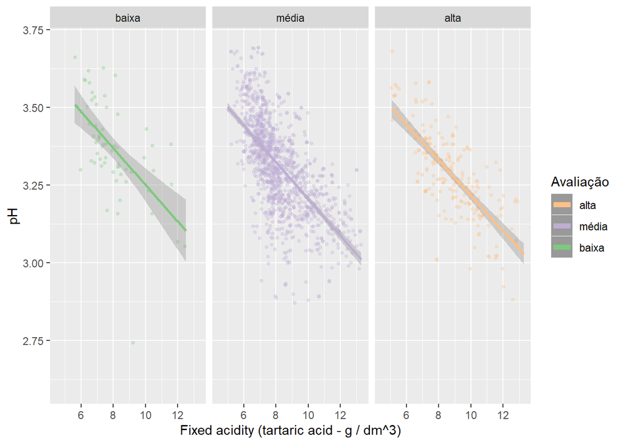

# Análise Multivariada

### Discuta sobre os relacionamentos observados nesta parte da investigação. Quais atributos que fortaleceram os demais na observação das variáveis de interesse?

Iniciei investigando o relacionamento entre as variáveis alcohol e volatile.acidity por terem o maior coeficiente de correlação com quality.E na representação gráfica é possível identificar a segmentação dos vinhos por teor alcoólico: vinhos com uma avaliação superior tendem a ter mais alcool. E os vinhos de avaliação inferior tendem para uma acidez maior.

### Interações surpreendentes e/ou interessantes foram encontradas entre os atributos?

Investiguei os relacionamentos entre: * Alcohol e Density, * Volatile.acidity e Citric.acid e * Fixed.acidity e pH

Sendo que em ambos os casos não houve reflexos significativos na variável quality.

Ao contrário de minhas suspeitas iniciais a variável residual.sugar não apresentou uma correlação que justificasse uma investigação aprofundada e acabou sendo descartada.

### OPCIONAL: Modelos foram criados usando este conjunto de dados? Discuta sobre os pontos fortes e as limitações do seu modelo.

Infelizmente não foi possível explorar a criação de modelos, mas essa possibilidade existe para conjunto de dados, tanto pelo tamanho do conjunto de amostras, quanto pelos relacionamentos entre as variaveis.

# Gráficos Finais e Sumário

### Primeiro Gráfico

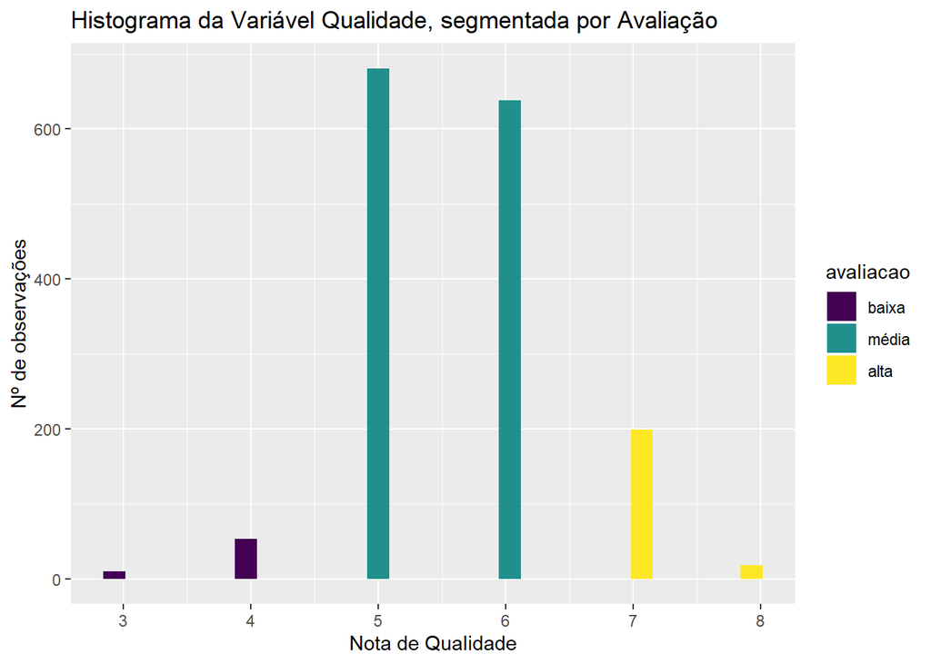

### Descrição do Primeiro Gráfico

O nosso conjunto de dados possui 1599 registros relacionados a vinhos tintos, sendo que cada um deles possui uma nota de qualidade. A representação gráfica apresenta estes registros num histograma, que é segmentado pela variavel avaliação, que nada mais é do que um categorização da nota de qualidade. Podemos verificar que a maior parte dos nossos registros pertencem a avaliação média.

### Segundo Gráfico

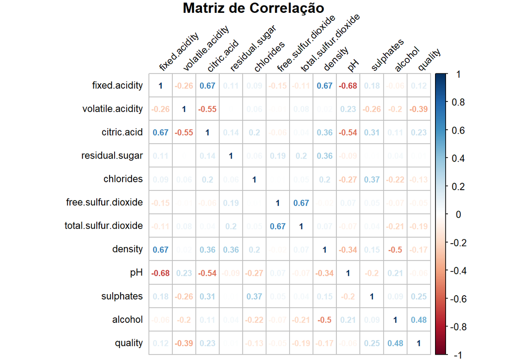

### Descrição do Segundo Gráfico

Pela matriz de correlação é possível identificarmos os relacionamentos que possuem os maiores coeficientes, para posteriormente direcionarmos as nossas análises. No caso, nossa varíavel de interesse é quality e as variáveis com maior correlação são: alcohol, volatile.acidity e sulphates.

### Terceiro Gráfico

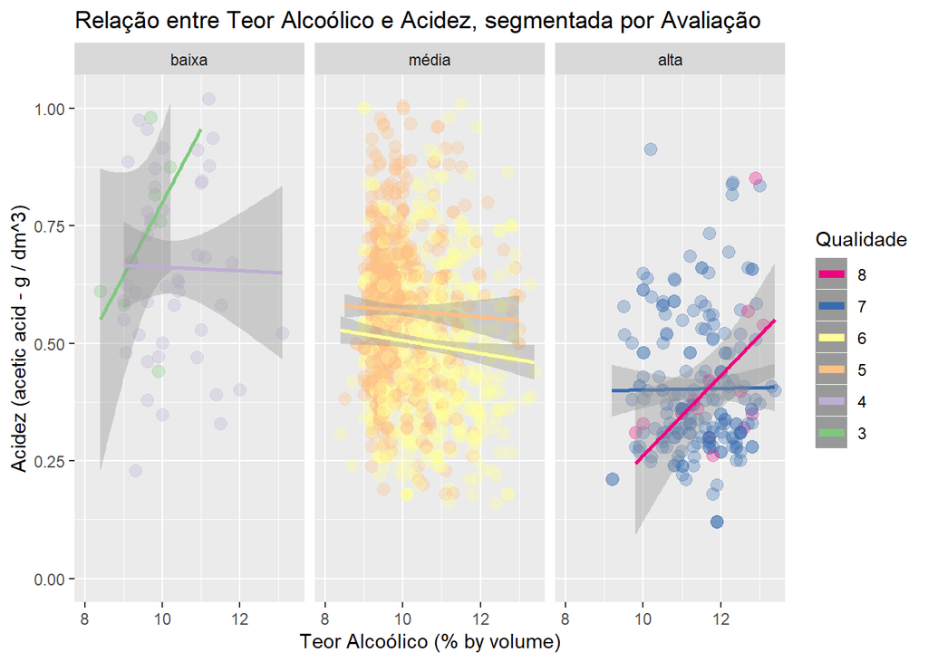

### Descrição do Terceiro Gráfico

A variável quality possui as maiores correlações com as variaveis: alcohol e volatile.acidity. No gráfico relacionamos alcohol e volatile.acidity, destacando a variável quality e segmentando a visualização por Avaliação. E podemos observar que há uma segmentação dos vinhos por teor alcoólico: vinhos com uma avaliação superior tendem a ter mais alcool. E os vinhos de avaliação inferior tendem para uma acidez maior.

# Reflexão

O nosso conjunto de dados possui 1599 observações e 13 variaveis, algumas delas relacionadas as propriedades químicas dos vinhos. Nossa intenção com este conjunto de dados é investigar quais propriedades químicas influenciam a qualidade dos vinhos tintos.

Inicialmente fomos conhecendo o conjunto de dados e obsevando o comportamento de cada uma das variáveis e ao elaborarmos a matriz de correlação foi possível identificar as variaveis que tem maior relação com qualidade, o que permitiu a condução de investigações mais aprofundadas.

Algumas suspeitas iniciais, como a influência do açucar residual na avaliação dos vinhos, mostraram-se com baixo impacto na avaliação final.

Para evitar a influencia de valores extermos (outliers), algumas representações foram restringidas à 99% das amostras.

Pelas análises realizadas foi possível constatar que o teor alcoólico e a acidez influenciam na avaliação de qualidade que um vinho receberá, mas outros fatores também podem refletir nesta avaliação, pois alguns vinhos com as notas mais altas possuem teor alcoólico e a acidez próximos aos vinhos de avaliação média.

Nos próximos estudos pretendo explorar ainda mais o conjunto de dados e tentar extrair algum modelo preditivo que determine qual seria a nota de qualidade atribuída a um vinho a partir de algumas características químicas. Outro estudo que pretendo realizar é a investigação se os fatores que influenciam a nota de qualidade de um vinho tinto são os mesmos para um vinho branco.

#Referências utilizadas:

- https://s3.amazonaws.com/content.udacity-data.com/courses/ud651/diamondsExample_2016-05.html
- http://rstudio-pubs-static.s3.amazonaws.com/198466_b17daa66ce6748a6a91cd27017608720.html
- http://rstudio-pubs-static.s3.amazonaws.com/53416_83b9685bc8c54afebcbb1e65a7c688fc.html
- https://rpubs.com/inageorgescu/whitewine2
- http://www.sthda.com/english/wiki/visualize-correlation-matrix-using-correlogram